# Individual Differences of Quantifier Interpretation

Alexandra Sarafoglou

November 2022

```r
setwd("~/GitProjects/MostQuantifiersHaveManyMeanings/dev")
library("dplyr")
library("MCMCpack")
library("LaplacesDemon")
library("rstan")
library("plotrix")
library(RColorBrewer)
library(corrplot)
library(factoextra)
library(psych)
library(MASS)
library(klaR)
library(rrcov)
library(olsrr) #SR
```

## The Task

In this task, participants have to evaluate whether a certain quantifier logically describes a scenario. Participants read a sentence in which a certain quantifier describes a scenario, for instance, “most of the gleerbs are fizzda”. Afterwards, the participants read the same sentence again, however, the quantifier is now replace with a percentage, that is, “20% of the gleerbs are fizzda”. The participant then needs to decide whether the statement is true or false. Percentages are drawn from a uniform ensuring that as many trials have more than 50% as have less than 50%. The quantifiers of interest are *Few*, *Fewer than half*, *Many*, *Most* and *More than half*. The idea is that *More than half* is defined by more than 50% for everyone while *Most* may be more subjective, and it may be more than *More than half* for everyone. Additionally, we may inspect the relationship between *Many* and *More than half*, and also symmetries between mirrored quantifiers.

### Model

Let $i$ indicate participants, $i = 1, \ldots, I$, $j$ indicate the quantifier, $j = 1, \ldots, 5$, and $k$ indicate the trial for each quantifier, $k = 1, \ldots, K_{ij}$.[^1] Then $Y_{ijk}$ is the $i$th participant’s response to the $j$th quantifier in the $k$th trial, and $Y_{ijk} = 1$ if participants indicate *true*, and $Y_{ijk} = 0$ if participant indicate *false*. Then, we may model $Y_{ijk}$ as a Bernoulli, using the logit link function on the probabilities:

$$\begin{align*}
Y_{ijk} &\sim \mbox{Bernoulli}(\pi_{ijk}),\\
\pi_{ijk} &= \gamma_{ij} + (1 - 2 \gamma_{ij})
\text{logit}^{-1}(\mu_{ijk}),\\
\end{align*}$$

$\pi_{ijk} = \gamma_{ij} + (1 - 2 \gamma_{ij}) \text{logit}^{-1}(\mu_{ijk})$

$$\begin{align*}
\gamma_{ij} &\sim \mbox{Beta}(2, 20),\\
\beta_{ij} &\sim \mbox{Normal}(\delta_j, \sigma_j^2),\\
\alpha_{ij} &\sim \mbox{log-Normal}(\nu_j, \sigma_{\alpha, j}^2),\\
\nu_j &\sim \mbox{Normal}(0, 5^2),\\
\sigma_{\alpha, j}^2 &\sim \mbox{Inverse-Gamma}(2, .2).\\
\delta_j &\sim \mbox{Normal}(0, 5^2).\\
\sigma^2_j &\sim \mbox{Inverse-Gamma}(2, .2).\\
\end{align*}$$

**Notes Julia:** These priors should be fairly wide and uninformative. Actually, the priors on $\nu$ and $\delta$ might be a bit too wide for a logit model. We might want to adjust these to standard normals.

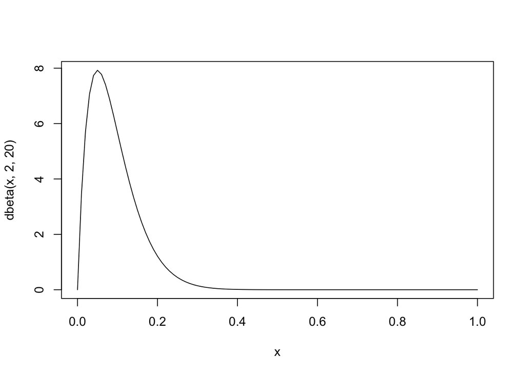

```r
# prior on gamma
curve(dbeta(x, 2, 20), from = 0, to = 1)
```

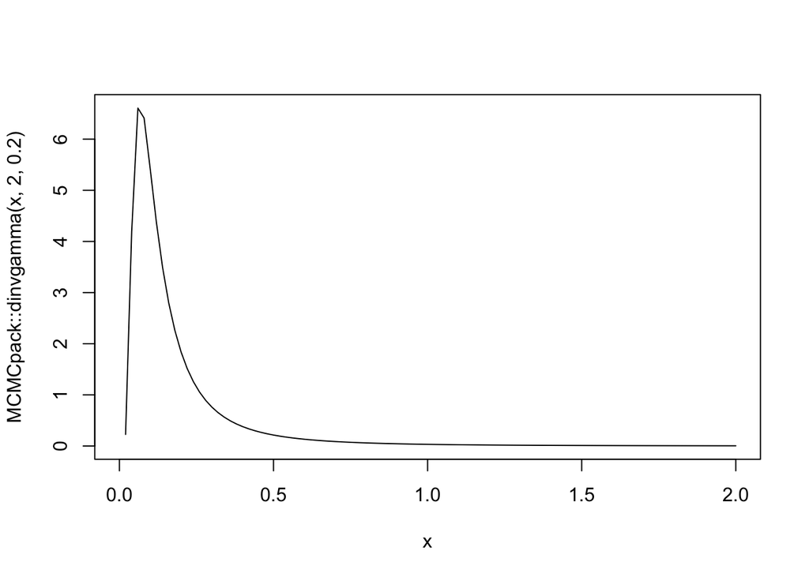

```r
# prior on sigma^2
curve(MCMCpack::dinvgamma(x, 2, .2), from = 0, to = 2)
```

[^1]: Originally, $K_{ij} = 50$. But this value may be reduced after cleaning on the trial level.